# Analiza zbioru dotycząca Irysów

## Wstęp

Analiza charakterystki 3 gatunków irysów w celu wsakazania ich cech fizycznych, co pozwoli czytelnikowi, który nigdy z nimi nie maił do czynienia na rozpoznanie poszczególnych gatunków.

## O Danych

Zbiór danych zawiera informacje o trzech gatunkach irysów: Iris setosa, Iris versicolor, i Iris virginica.

Dane obejmują pomiary czterech cech: długość i szerokość działki kielicha oraz długość i szerokość płatka.

Każdy wiersz w zbiorze danych reprezentuje pojedynczy kwiat, a wartości pomiarów są podane w centymetrach.

Zbiór składa się z 150 próbek, po 50 dla każdego gatunku, i jest szeroko stosowany jako podstawowy zbiór danych do testowania algorytmów klasyfikacji oraz w nauce o danych i uczeniu maszynowym.

Kolumny:

- **długość kielicha (sepal length)** - Długość kielicha w cm
- **szerokość kielicha (sepal width)** - Szerokość kielicha w cm
- **długość płatka (petal length)** - Długość płatka w cm
- **szerokość płatka (petal width)** - Szerokość płatka w cm
- **klasa (class)** - Klasa irysa (setosa, versicolor, virginica)

## Cel analizy:

Wsakazanie cech fizycznych, poszczególnych gatunków pozwalające na rozpoznanie poszczególnych gatunków.

# KROK 1: Transformacja danych

Po przyjrzeniu się charakterystyki danych zmienione zostały nazwy kolumn w celu poprawy ich czytelnośći.

Stworzenie kopi dataframe.

Przeniesienie kolumny z nazwami na początek dla lepszej czytelności.

Uproszczenie nazw na czytelności.

# KROK 2: Techniczny przegląd danych

### Podstawowe statystyki opisowe

Dane zawierają **150** wierszy i **5** kolumn.

#### Dane opisowe

|  | count | mean | std | min | 25% | 50% | 75% | max |
| --- | --- | --- | --- | --- | --- | --- | --- | --- |
| Długość kielicha | 150.0 | 5.843333 | 0.828066 | 4.3 | 5.1 | 5.80 | 6.4 | 7.9 |
| Szerokość kielicha | 150.0 | 3.054000 | 0.433594 | 2.0 | 2.8 | 3.00 | 3.3 | 4.4 |
| Długość płatka | 150.0 | 3.758667 | 1.764420 | 1.0 | 1.6 | 4.35 | 5.1 | 6.9 |
| Szerokość płatka | 150.0 | 1.198667 | 0.763161 | 0.1 | 0.3 | 1.30 | 1.8 | 2.5 |

#### Informacje techniczne o DataFrame

|  | Kolumna | Typ danych | Nie-null | Unikalne |
| --- | --- | --- | --- | --- |
| 0 | Podgatunek | object | 150 | 3 |
| 1 | Długość kielicha | float64 | 150 | 35 |
| 2 | Szerokość kielicha | float64 | 150 | 23 |
| 3 | Długość płatka | float64 | 150 | 43 |
| 4 | Szerokość płatka | float64 | 150 | 22 |

### Wartości unikatowe

|  | Kolumna | Liczba unikatowych wartości |
| --- | --- | --- |
| 0 | Podgatunek | 3 |
| 1 | Długość kielicha | 35 |
| 2 | Szerokość kielicha | 23 |
| 3 | Długość płatka | 43 |
| 4 | Szerokość płatka | 22 |

# KROK 3: Ogólny przegląd danych

### Wartości minimalne i maxymalne dla każego z gatunków oraz ich części

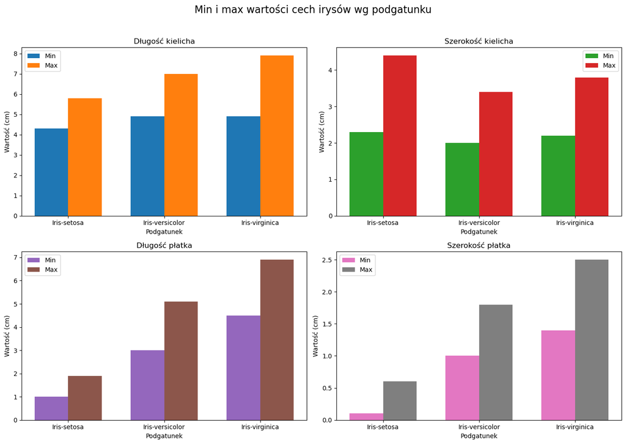

### Wnioski na podstawie wykresów słupkowych oraz wartości maksymalnych i minimalnych cech fizycznych irysów

# KROK 4: Analiza pojedyńczych zmiennych

## Histogramy cech fizycznych dla każdego gatunku irysów

#### Iris-setosa

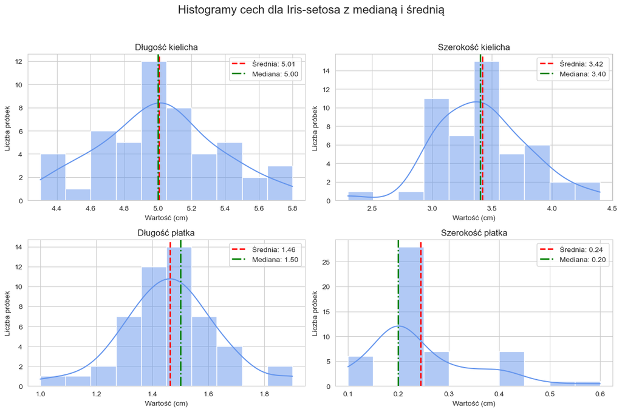

1. Długość kielicha:
   - Rozkład dość symetryczny i skupiony wokół 5.0 cm.
   - Średnia ≈ Mediana → dane są dobrze zbalansowane, brak silnej asymetrii.
   - Kształt przypomina rozkład normalny.
2. Szerokość kielicha:
   - Podobnie jak wyżej, bardzo symetryczny rozkład – średnia i mediana prawie identyczne.
   - Widać lekkie zagęszczenie wokół 3.4–3.5 cm.
   - Można wnioskować, że to cecha stabilna w populacji Iris-setosa.
3. Długość płatka:
   - Tu pojawia się lekka asymetria lewostronna (średnia < mediana).
   - Może to oznaczać kilka próbek z mniejszą niż zwykle długością płatka, które zaniżają średnią.
   - Większość wartości skupiona wokół 1.4–1.6 cm.
4. Szerokość płatka:
   - Średnia: 0.24 cm, Mediana: 0.20 cm
   - Widoczna wyraźna asymetria prawostronna (średnia > mediana).
   - Dużo próbek z niskimi wartościami, ale też kilka z wyraźnie wyższymi → podnoszą średnią.
   - Średnia jest mniej reprezentatywna niż mediana.

#### Iris-versicolor

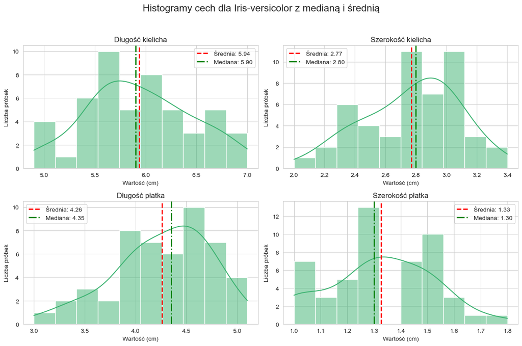

1. Długość kielicha:
   - Wartości średniej i mediany są bardzo zbliżone, co sugeruje symetryczny rozkład (lub bliski symetrycznemu).
   - Histogram lekko przechylony w prawo (mały ogon), ale nieznacznie.
   - Brak wyraźnych odstających wartości, długość kielicha rozkłada się dość równomiernie.
2. Szerokość kielicha:
   - Mediana nieco większa niż średnia → lekkie przechylenie rozkładu w lewo.
   - Histogram pokazuje delikatny ogon po lewej stronie.
   - Większość wartości skupia się wokół 2.8, ale jest kilka mniejszych przypadków.
3. Długość płatka:
   - Średnia niższa niż mediana → wyraźniejsze przechylenie w lewo (lewy ogon).
   - Histogram ma bardziej rozciągnięty rozkład niż poprzednie.
   - Cechuje się większym zróżnicowaniem – niektóre kwiaty mają znacznie krótsze płatki niż większość.
4. Szerokość płatka:
   - Tym razem średnia nieco większa niż mediana → lekkie przechylenie w prawo.
   - Większość wartości skupia się między 1.2 a 1.5 cm.
   - Rozkład stosunkowo wąski, choć z pojedynczymi większymi wartościami.

📌 Ogólne wnioski:

- Rozkłady dla Iris-versicolor są dość zrównoważone, ale mają delikatne przechylenia (szczególnie długość i szerokość płatka).
- Długość płatka ma największe zróżnicowanie (szeroki rozkład).
- Szerokość kielicha i szerokość płatka są bardziej skoncentrowane.

#### Iris-virginica

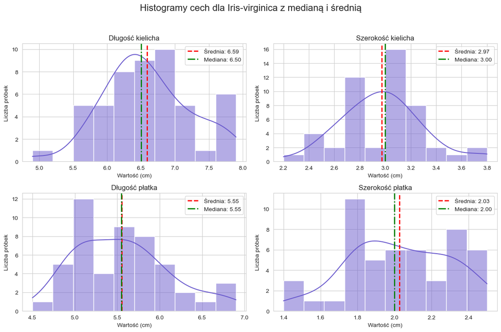

1. Długość kielicha:
   - Średnia jest nieco wyższa od mediany, co sugeruje lekkie przechylenie w prawo – ogon rozkładu jest dłuższy po stronie wyższych wartości.
   - Dane są ogólnie rozłożone symetrycznie, ale z niewielką ilością większych wartości.
2. Szerokość kielicha:
   - Mediana minimalnie przewyższa średnią, co oznacza delikatne przechylenie w lewo.
   - Większość danych znajduje się wokół 3.0 cm, z lekką obecnością niższych wartości, co może świadczyć o lekkim spłaszczeniu rozkładu.
3. Długość płatka:
   - Pokrycie się średniej i mediany wskazuje na idealnie symetryczny rozkład.
   - Cecha ta ma bardzo równomierny rozkład wartości, bez wyraźnych odstających.
4. Szerokość płatka:
   - Średnia jest nieco wyższa od mediany, co oznacza niewielkie przechylenie w prawo.
   - Histogram pokazuje wyraźny pik przy 1.8–2.0 cm oraz kilka wyższych wartości (2.3–2.5), co przesuwa średnią.

🔍 Wnioski ogólne:

- Długość i szerokość płatków u Iris-virginica są większe niż u innych odmian, co czyni je dobrymi cechami dyskryminacyjnymi.
- Rozkłady są generalnie symetryczne lub lekko skośne, bez ekstremalnych wartości odstających.
- Cecha „Długość płatka” ma najbardziej zrównoważony rozkład spośród wszystkich.

# Krok 5: Analiza korelacji

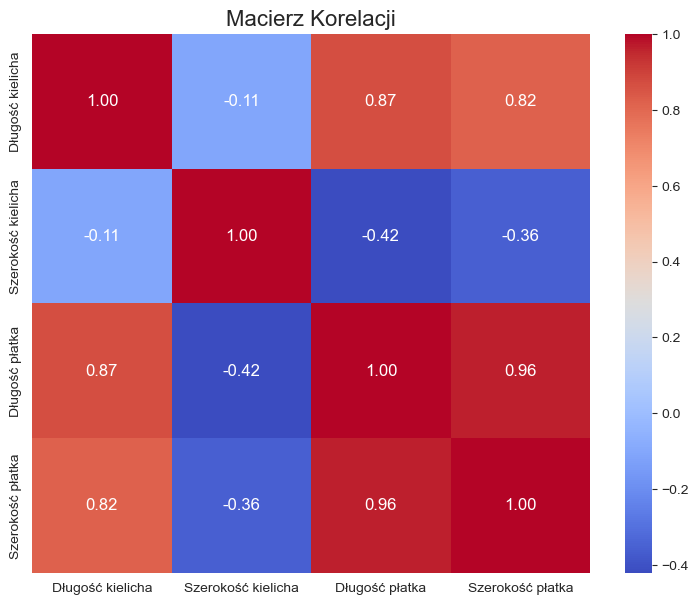

### Na podstawie analizy wykresu Macierzy korelacji można stwierdzić że:

wystempuje silna korelacja między:

- długością kielicha a długością płatka: 0,87
- długością kielicha a szerokością płatka: 0,82
- długością płatka a szerokością płatka: 0,96

słaba korelacja ujemna między:

- długością płatka a szerokością kielicha: -0,42
- szerokością płatka a szerokością kielicha: -,36

Słaba korelacja ujemna miedzy:

- szerokością kielicha a długością kielicha: -0,11

📌 Wnioski ogólne: Najsilniejsze zależności dodatnie występują pomiędzy wymiarami płatków. To oznacza, że długość i szerokość płatka są ze sobą ściśle powiązane.

Kielich jest silnie związany z długością i szerokością płatka (szczególnie długość kielicha), co może wskazywać na wspólne uwarunkowania wzrostu.

Szerokość kielicha wydaje się mieć negatywny wpływ na rozmiar płatków — jest to nietypowe i może wskazywać na wewnętrzną równowagę w budowie kwiatu tej odmiany.

Długość a szerokość kielicha nie wykazują silnej korelacji – te dwie cechy zmieniają się niezależnie.

# Krok 6: Analiza danych odstających

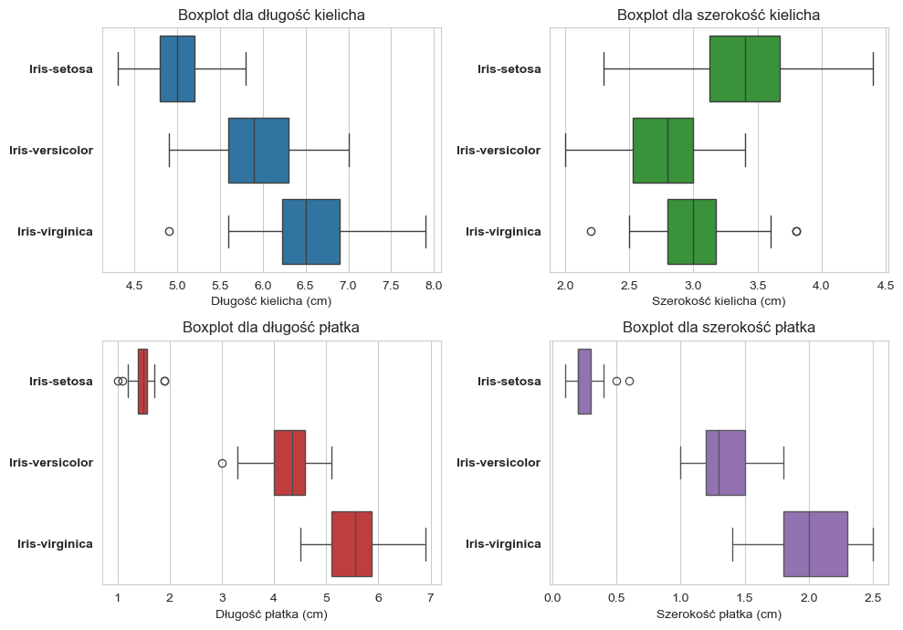

### Podsumowanie Analizy wartości odstających

- Dla każdego podgatunku irysa występują wartości odstające
- Ich zakres wacha się od 2% do 6%, jest raczej pomijalny
- można stwierdzić że są pomijalne oprócz Długości płatka dla Iris-setosa, 6% jest już zauważalne

Również na podstawie boxplotów można stwierdzić że najbardziej bujne płatki posiada Iris-virginica ustępujący jedynie szerokością kielicha. Najdrobniejszy jest Iris-setosa, jedynie przewyższa, szerkością kielicha. Natomiast Iris-versicolor jest najbardziej uśredniony.

# Krok 7: Podsumowanie analizy dotyczących irysów

### Analizowane były 3 gatunki irysów: Iris-setosa, Iris-versicolor, Iris-virginica.

Wnioski a założone cele:

- **Iris-virginica** najbardziej rozbudowanym podgatunkiem irysa, posiada najdłuższy i najszerszy płatek oraz najdłuższy kielich. Ustępuje jedynie szerokością kielicha dla Iris-setosa
- **Iris-versicolor** najbardziej uśredniony spośród podgatunków irysa. Jest najtrudniej rozpoznawany i najłatwiej go pomylić z Iriys-virginica ponieważ zakresy długości i szerokości kielicha lekko na siebie zachodzą
- **Iris-setosa** jest najmniej okazały i jednocześnie najbardziej rozpoznawany pośród analizowanych kwiatów. Posiada najszerszy i najkrótszy kielich jednocześnie jego płatki są najkrótsze i najwęższe ze wszystkich. Bardzo łatwy do rozpoznania.
- Największe różnice występują między **Iris-setosa** a **Iris-virginica**. Najłatwiej je od siebie odróżnić

### Dla porówniania zdjęcia każdego z Irysów

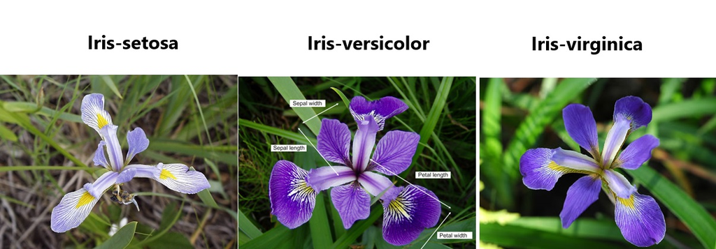